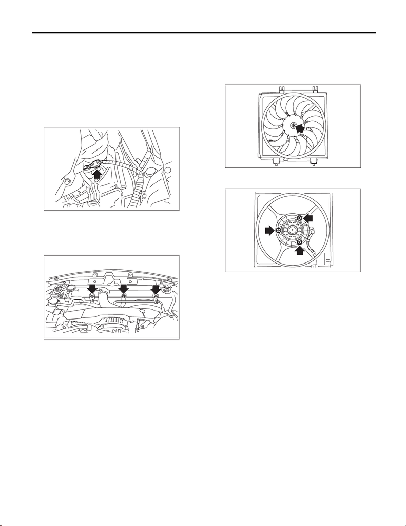

Radiator Sub Fan and Fan Motor

COOLING

9. Radiator Sub Fan and Fan

Motor

A: REMOVAL

1) Disconnect the ground cable from battery.

2) Lift up the vehicle.

3) Remove the under cover. <Ref. to EI-21, RE-

MOVAL, Front Under Cover.>

4) Disconnect the connector from the sub fan mo-

tor.

5) Lower the vehicle.

6) Remove the air intake duct. <Ref. to IN(STI)-11,

REMOVAL, Air Intake Duct.>

7) Remove the bolts which secure the radiator sub

fan motor assembly and the over flow pipe.

8) Raise the radiator sub fan motor assembly

slightly, remove the pin at the lower part of the ra-

diator sub fan motor assembly from the radiator

hole, and remove the radiator sub fan motor as-

sembly from the lower side of the vehicle.

B: INSTALLATION

Install in the reverse order of removal.

CAUTION:

Check if the radiator hose and the over flow

hose are properly connected.

Tightening torque:

7.5 N·m (0.8 kgf-m, 5.5 ft-lb)

C: DISASSEMBLY

1) Remove the clip which holds the sub fan motor

connector onto the radiator sub fan shroud.

2) Disconnect the radiator sub fan from the sub fan

motor.

3) Disconnect the sub fan motor from the radiator

sub fan shroud.

CO-02413

CO-02369

CO-02373

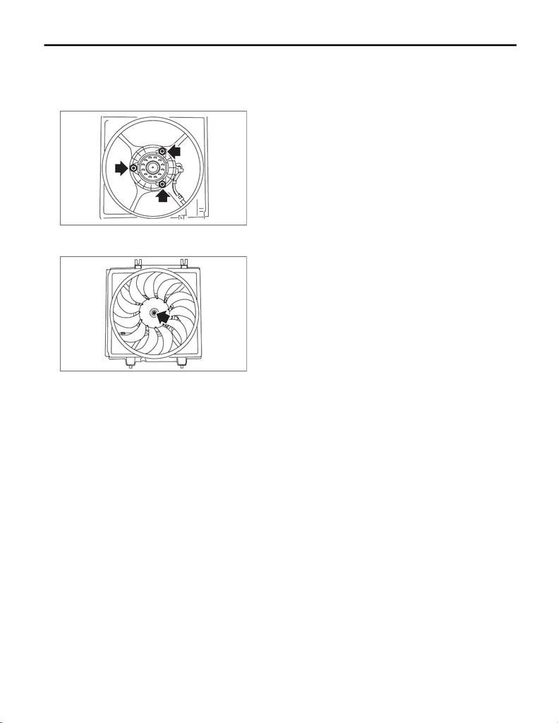

Radiator Sub Fan and Fan Motor

COOLING

D: ASSEMBLY

Assemble in the reverse order of disassembly.

Tightening torque:

4.41 N·m (0.45 kgf-m, 3.25 ft-lb)

Tightening torque:

3.4 N·m (0.3 kgf-m, 2.5 ft-lb)

E: INSPECTION

Check that the radiator sub fan, radiator sub fan

shroud and sub fan motor do not have deformation,

cracks or damage.

CO-02373

CO-02369